# Jackknife Variance Estimator for Datasets Containing Multiply Imputed Outcome Variables Under Uncongeniality: A Monte Carlo Simulation Study

Ihsan E. Buker & Samantha R. Seals

Department of Mathematics and Statistics, University of West Florida

# Background

Missing data is a discipline-agnostic issue commonly encountered by statistical practitioners. Given that many statistical procedures require data to be complete (i.e., in the form of an $n \times m$ matrix), the appropriate course of action to be taken in the presence of missing data has long been investigated by statisticians. Today, multiple imputation is accepted as the gold standard in missing data analysis, thanks to the work of Donald Rubin (Buuren 2012). In 1977, Rubin proposed using multiple completed versions of the dataset with missing observations, applying the complete-data procedure of interest, and pooling the estimates to draw valid inferences (Buuren 2012). The main advantage of multiple imputation, as opposed to single imputation, which had been used by researchers since the early 1970s, is its ability to properly estimate the variance caused by missing observations (Buuren 2012). The emphasis placed on variance and uncertainty by Rubin was a departure from the status quo of the time, which was to fill in the missing observation with the most probable value and to proceed with complete case analyses as if the observation had not been missing, to begin with (Buuren 2012). This approach, however, fails to incorporate the loss of information caused by missing observations into the estimation of parameters, resulting in the underestimation of variance (Rubin 1978).

Like all revolutionary ideas, multiple imputation received harsh criticism following its conception. Perhaps the most notable of the objections came from Fay in 1992, who demonstrated through counterexamples that multiple imputation produced biased covariance estimates (Jonathan W. Bartlett and Hughes 2020). Fay added that the need for unison between the imputation and analysis model made multiple imputation a poor general-purpose tool, particularly in instances where the imputer and analyst are different individuals (Fay 1992; Buuren 2012). Fay’s arguments led to the conceptualization of congeniality[^1] between the imputation and analysis model, which was later accepted to be a requirement to obtain valid inferences from multiple imputation using Rubin’s pooling rules (hereafter, Rubin’s rules) (Buuren 2012; Meng 1994). Briefly, uncongeniality refers to the imputation and analysis model making irreconcilably different assumptions regarding the data, which occurs rather frequently in practice (Jonathan W. Bartlett and Hughes 2020). Although Fay’s work initially criticized biases introduced to the covariance matrix following multiple imputation, a similar phenomenon of biased estimates were observed with variance estimators under uncongeniality (Fay 1992; Meng 1994; Xie and Meng 2016).

Some of the earliest works demonstrating Rubin’s variance estimator to be biased under uncongeniality were from Wang and Robins in 1998, who also proposed an alternate variance estimator in the same paper (Buuren 2012). The variance estimator proposed by Wang and Robins requires the calculation of several quantities, which are not easily accessible to the average statistical practitioner (Jonathan W. Bartlett and Hughes 2020). The challenging construction of the variance estimator proposed by Wang and Robins has resulted in it receiving little-to-no attention in applied settings (Jonathan W. Bartlett and Hughes 2020). In an attempt to create a more user-friendly variance estimator in instances of suspected uncongeniality, researchers have proposed combining resampling methods with multiple imputation. Of the two main resampling methods, bootstrap has received more attention from multiple imputation researchers compared to jackknife resampling, which has mostly been investigated under single hot-deck imputation. Although particular combinations of bootstrap and multiple imputation have been demonstrated to create asymptotically unbiased estimates of variance, the associated computational cost makes this an active area of research (Jonathan W. Bartlett and Hughes 2020). Most recently, von Hippel has proposed a bootstrap variance estimator which addresses the issue of computational cost; however, it has been demonstrated to create confidence intervals that are slightly wider compared to traditional bootstrap and multiple imputation combinations (Jonathan W. Bartlett and Hughes 2020). Given the lower computational cost associated with jackknife resampling, as well as desirable properties demonstrated under single imputation, such as being unbiased in certain scenarios, it is an attractive alternative that should be considered as a variance estimator of multiply imputed data under uncongeniality (Chen and Shao 2001; Rao and Shao 1992). More importantly, however, is the advantages jackknife resampling has over bootstrap resampling in small sample sizes, which are frequently encountered in datasets associated with biological studies.

## Bootstrap Resampling

Let $q$ be the set of observations $\left(z_1, z_2, z_3, \dots, z_n \right)$ from the population $Q$ such that $z_i \ \forall \ i \in \{1, 2, 3, \dots, n\}$ is an i.i.d[^2] sample from $Q$. Moreover, let $\theta$ be some parameter of interest, with the unbiased estimator $\hat{\theta}$, which is a statistic computed from $F(q)$. Finally, let $G_{\theta}$ be the sampling distribution of $F(q)$. The non-parametric bootstrap, as proposed by Efron, lets $q$ define $Q$ such that the set of observations $\left(z_1, z_2, z_3, \dots, z_n \right)$ appears with equal proportion in the infinitely large population. From there, the set of samples $q^*_1, q^*_2, q^*_3, \dots, q^*_m$ as $m \rightarrow \infty$ are generated by sampling $n$ observations with replacement from $q$, and the statistic of interest $\hat{\theta}$ is calculated by applying $F(q_i) \ \forall \ i \in \{1, 2, 3, \dots, m\}$, which results in $\hat{\theta^*}_1, \hat{\theta^*}_2, \hat{\theta^*}_3, \dots, \hat{\theta^*}_m$.

Finally, the point estimate is obtained by

$$\hat{\theta} = m^{-1}\sum^m_{i = 1}
\hat{\theta^*}_i$$

and the variance is obtained by

$$\text{var}(\hat{\theta}) =
m^{-1}\sum^m_{i = 1} \left(\hat{\theta^*}_i -
\hat{\theta}\right)^2$$

Since Efron’s proposal of the non-parametric bootstrap, statisticians have widely utilized it thanks to its ease of implementation and the rapidly increasing computational power available to statistical practitioners (LaFontaine 2021). However, the properties of bootstrap resampling have their basis in the asymptotic theory, which holds in large sample sizes (Wang 1998; Mammen 1992). The minimum sample size required to utilize bootstrap resampling and obtain asymptotically unbiased estimates is highly context-dependent; in certain situations, a minimum sample size of $n = 200$ has been suggested, with other authors suggesting between $n = 100$ to $n = 500$ (Anderson and Gerbing 1984; Bentler and Chou 1987; Jackson 2001). Given that in many biological studies, the minimum sample size required for asymptotically unbiased estimates may not be achieved, jackknife resampling, a method that predates the bootstrap, may be considered (Faber and Fonseca 2014).

## Jackknife Resampling

### Leave-One-Out Jackknife

Let $q$ be the set of observations $\left(z_1, z_2, z_3, \dots, z_n \right)$ from the population $Q$ such that $z_i \ \forall \ i \in \{1, 2, 3, \dots, n\}$ is an i.i.d sample from $Q$. Moreover, let $\theta$ be some parameter of interest, with the unbiased estimator $\hat{\theta}$, which is a statistic computed from $F(q)$. Finally, let $G_{\theta}$ be the sampling distribution of $F(q)$. The jackknife, as proposed by Quenouille and expanded on by Tukey, creates $n$ leave-one-out subsamples from $q$ such that $q_{-1} = \left(z_2, z_3, z_4, \dots, z_n \right),$ $q_{-2} = \left(z_1, z_3, z_4, \dots, z_n \right), \dots, q_{-n} = \left(z_1, z_2, z_3, \dots, z_{n-1} \right)$ and $\lvert q_{-i}\rvert = n-1 \ \forall i \in \{1, 2, 3, \dots, n\}$. Thereafter, the statistic of interest $\hat{\theta}$ is calculated by applying $F(q_i) \ \forall \ i \in \{1, 2, 3, \dots, n\}$, which results in $\hat{\theta^*}_1, \hat{\theta^*}_2, \hat{\theta^*}_3, \dots, \hat{\theta^*}_m$.

Finally, the point estimate is obtained by

$$\hat{\theta} = n^{-1}\sum^n_{i = 1} \hat{\theta^*}_i$$

and the variance is obtained by

$$\text{var}(\hat{\theta}) = n^{-1}\sum^n_{i = 1} \left(\hat{\theta^*}_i -
\hat{\theta}\right)^2$$

### Delete-*d* Jackknife

The delete-*d* jackknife may be seen as a generalized version of the traditional jackknife (hereinafter, jackknife). Although in many situations, the jackknife provides a computationally efficient means to estimate the variance of an estimator, it fails with non-smooth statistics. For non-smooth statistics, such as the percentiles of the data, the jackknife fails because the statistic varies significantly between any two subsamples (Chen and Shao 2001). In such cases, the delete-*d* jackknife provides an alternative estimator that can provide asymptotically unbiased estimates for non-smooth statistics (Rao and Shao 1992). Similarly, let $q$ be the set of observations $\left(z_1, z_2, z_3, \dots, z_n \right)$ from the population $Q$ such that $z_i \ \forall \ i \in \{1, 2, 3, \dots, n\}$ is an i.i.d sample from $Q$. Moreover, let $\theta$ be some parameter of interest, with the unbiased estimator $\hat{\theta}$, which is a statistic computed from $F(q)$. Finally, let $G_{\theta}$ be the sampling distribution of $F(q)$. The delete-*d* jackknife, creates $n \choose d$ subsamples of $q$ such that $\lvert q_i \rvert = n-d$ Thereafter, the statistic of interest $\hat{\theta}$ is calculated by applying $F(q_i) \ \forall \ i \in \{1, 2, 3, \dots, {n \choose d} \}$, which results in $\hat{\theta^*}_1, \hat{\theta^*}_2, \hat{\theta^*}_3, \dots, \hat{\theta^*}_{n \choose d}$. In many cases, however, $n \choose d$ is a large value that yields this approach computationally unfeasible. In such instances, certain guidelines, as discussed in following chapters, may be employed to determine a value of subsamples that still provide proper estimates.

Finally, the point estimate is obtained by

$$\hat{\theta} = {n \choose d}^{-1}\sum^{n \choose d}_{i = 1}
\hat{\theta^*}_i$$

and the variance is obtained by

$$\text{var}(\hat{\theta}) = {n \choose d}^{-1}\sum^{n \choose d}_{i = 1}
\left(\hat{\theta^*}_i - \hat{\theta}\right)^2$$

## Comparison of Jackknife and Bootstrap Resampling

Given their comparable construction and application, the jackknife and bootstrap make similar assumptions regarding the data. Most notably, both assume that the function used to estimate the parameter is smooth. Formally, a smooth function is defined as one that has continuous derivatives over some domain, with the minimum number of derivatives required to be considered smooth varying per the question at hand (Weisstein, n.d.). From a statistical perspective, if the function used to estimate the parameter is smooth on some domain $(a, b)$, $[F(q_i) - F(q_z)] \rightarrow 0$ as $\lvert q_i - q_z\rvert \rightarrow 0$. Meaning, among a set of conceivable, non-identical samples from the population, minor differences between possible samples will only result in minor differences between the statistic estimated (Chen and Shao 2001). Due to its deterministic nature, the jackknife tends to perform poorly in estimating non-smooth statistics (Wicklin 2017). However, its deterministic nature also yields the jackknife superior to bootstrapping in smaller datasets. To combat the issue regarding non-smooth statistics, a generalized jackknife resampling scheme, called the *drop-d-jackknife* has been proposed, which was utilized in this estimator (Chen and Shao 2001).

## Multiple Imputation

Multiple imputation is a missing data management method based on both Bayesian and frequentist inference proposed by Donald Rubin in the late 1970s (Jonathan W. Bartlett and Hughes 2020; Buuren 2012). Before Rubin’s proposal, statisticians had been utilizing various single-imputation methods and proceeding with the analyses of interest as if data had not been missing. However, Rubin noted that single-imputation methods could not accurately capture the uncertainty caused by the missing observations (Buuren 2012). In response, he proposed imputing any given datum with a series of plausible values from its posterior distribution, thus creating several complete versions of the observed dataset and applying the complete data analysis procedure to each generated dataset. He proposed a series of rules that could derive point and variance estimates that would adequately reflect the uncertainty caused by the missing observations.

Rubin’s idea to utilize multiple imputation was ridiculed at first, not only due to its drastically different interpretation of uncertainty but because of how unfeasible it was at the time (Buuren 2012). Rubin’s method would require statisticians to come up with an imputation model that would allow them to draw values from the posterior distribution. After that, they would have to draw several values and repeat the analysis multiple times with the numerous complete datasets. The preceding workflow was challenging to implement in an era of low computational power and expensive digital storage (Buuren 2012). As such, Rubin’s ideas did not receive immediate acceptance. However, since the late 1990s, with the increased access to computers and user-friendly statistical packages capable of implementing complex procedures, multiple imputations have been adopted and heavily researched, leading to various modified algorithms being utilized under different conditions to obtain valid inferences in the presence of missing data (Buuren 2012). At this time, one of the most notable challenges remaining with multiple imputation is the concept of congeniality. Congeniality may be thought of as the imputation model and the analysis model making compatible assumptions regarding the data. In the early 1990s, Fay and Meng demonstrated that congeniality was required to obtain valid inferences from multiple imputation (Jonathan W. Bartlett and Hughes 2020; Jonathan W. Bartlett 2021).

### Current State of Multiple Imputation

Today, with the advent of public databases, the imputer and the analyst may no longer be the same person. Even in the absence of such cases, the imputation and analysis model may still be uncongenial if there does not exist a unifying Bayesian model which embeds the imputer’s imputation model and the analyst’s complete data procedure (Jonathan W. Bartlett 2021). As such, researchers have begun to develop approaches that combine resampling methods with multiple imputation to obtain valid inferences even under uncongeniality. Of the currently proposed methods, there exist two main limitations: a) the increased computational cost brought on by resampling methods alongside multiple imputation, and b) inference in smaller sample sizes. At this time, nearly all mainstream approaches proposed by researchers utilize bootstrap resampling and multiple imputation to obtain valid inferences under uncongeniality; however, as discussed above, bootstrap resampling requires a certain sample size to provide proper estimates. As a viable alternative to be utilized in instances where there is a small sample size, a jackknife variance estimator is proposed.

# The Proposed Jackknife Estimator

A pseudocode overview of the jackknife estimator proposed may be seen in the following figure.

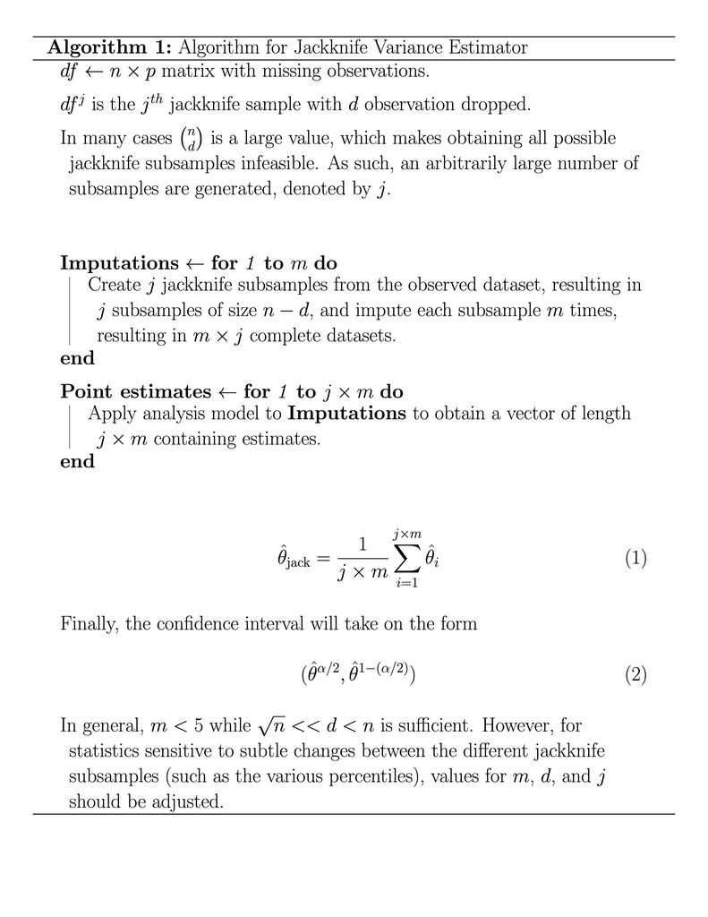

A pseudocode depiction of the proposed estimator.

Briefly, the algorithm begins by obtaining $j$ jackknife subsamples from the observed dataset with missing observations. Thereafter, each of the $j$ subsamples are imputed $m$ times, resulting in a total of $j \times m$ complete datasets. Subsequently, the analysis model of interest to estimate $\theta$ is applied to each of the completed datasets to produce $\hat{\theta^*}_1, \hat{\theta^*}_2, \hat{\theta^*}_3, \dots, \hat{\theta^*}_{n \choose d}$. The point estimate then becomes the mean of the previously produced $n$ pseudo-estimates. As for the confidence interval, the $\alpha/2^{th}$ and $1-\alpha/2^{th}$, values serve as the lower and upper bounds, respectively.

As part of the algorithm, researchers must choose values $d$ and $j$, which will be context-dependent quantities. Ideally, a $d$ value which satisfies $\frac{\sqrt{n}}{d} \rightarrow 0$ will provide asymptotically unbiased estimates even for non-smooth statistics (Chen and Shao 2001; Shao and Wu 1989). Rewriting the foregoing condition for $d$

$$\begin{align}
&\frac{\sqrt{n}}{d} \rightarrow \ 0 \\
&\implies d >> \sqrt{n} \\
&\text{Since} \ n > d \\
&\implies n > d >> \sqrt{n}
\end{align}$$

It is evident that $d$ should take on some value between $n$ and $\sqrt{n}$ with $d$ being closer to $n$, particularly for non-smooth statistics. At any rate, $j = {n \choose d}$ will likely be a value that is not computationally feasible to obtain. As such, the number of subsamples required, $j$, can be limited to yield the estimator more accessible. The choice of $j$ will be a multifaceted decision, where, if possible, greater values are preferred. Ideally, a small pilot study may be performed with a range of $j$ values to determine values of $j$ for which estimates begin to converge.

Although not as widely applicable, researchers may consider utilizing a delete-one jackknife, as discussed previously. Given the stochastic nature of multiple imputation, especially in instances where a high proportion of missingness is present, the pseudo-estimates may vary widely between any two given jackknife subsamples, similar to what would be observed in the case of percentiles. As such, the delete-one jackknife approach is not recommended for general use but could be considered in samples with low missingness proportion.

# Methods

For the proposed Monte Carlo simulation, $N$ = 30,000 datasets were generated with the following characteristics: A response variable, $Y$, where the proportion of missingness varied among 10%, 30%, and 50% of the observations with the mechanism of missingness being missing at random (MAR), and an $n \times q$ matrix of fully observed covariates, where $n = 50$ was the sample size, and $q = 3$ the number of covariates.

Formally

$$\begin{bmatrix} V1 \\V2 \\ V3 \end{bmatrix} \sim N\left(\begin{bmatrix}
1\\ 1 \\ 1 \end{bmatrix}, \begin{bmatrix} 1 & 0.5 & 0.5 \\
0.5 & 1 & 0.5 \\
0.5 & 0.5 & 1
\end{bmatrix}\right)$$
With

$$\beta_{V_1} = 2 ; \ \beta_{V_2} = 5 ; \ \beta_{V_3} = 8$$
The outcome variable was simulated such that:

$$Y = V_1 + V_2 + V_3 + \epsilon$$
Where

$$\epsilon \sim N(\mu = 0, \sigma \propto V_2)$$

Thus, data were simulated with heteroskedastic errors, which yields the imputation and analysis models congenial, yet misspecified.

Formally, the analysis model of interest was

$$\widehat{Y} \sim \widehat{\beta}_{V_1} + \widehat{\beta}_{V_2} +
\widehat{\beta}_{V_3}$$

And the imputation model was

$$\widehat{Y}_{\text{mis}} \sim \widehat{\beta}_{V_1} +
\widehat{\beta}_{V_2} + \widehat{\beta}_{V_3}$$

Where the imputation method of choice was predictive mean matching (PMM).

All generated datasets were analysed using three approaches:

- **Bootstrap then multiply impute:** The observed dataset with missing observations was initially bootstrapped $n = 200$ times. Thereafter, each of the bootstrap samples were imputed $m = 2$ times, with a maximum of $maxit = 5$ iterations. The mean of the bootstrap estimates served as the final point estimate, and a 95% confidence interval was generated through the percentile method, where the $\alpha/2^{th}$ and $1-(\alpha/2)^{th}$ percentiles were the lower and upper bounds, respectively. The R package, *bootImpute* was utilized for this process.
- **Multiply impute then use Rubin’s rules:** The observed dataset with missing observations was imputed $m = 10$ times, with a maximum of $maxit = 5$ iterations. The point estimate, as well as the confidence interval was obtained through the following rules proposed by Donald Rubin. The *mice* package was utilized for this process.

$$\begin{align}
\bar{\theta} &= \frac{1}{m}\left (\sum_{i=1}^m{\theta_i}\right ) \\
V_{\text{within}} &= \frac{1}{m} \sum_{i=1}^m{SE_i^2} \\
V_{\text{between}} &= \frac{\sum_{i=1}^m (\theta_i -
\overline{\theta})^2}{m-1} \\
V_{\text{total}} &= V_W + V_B + \frac{V_B}{m} \\
\bar{\theta} &\pm t_{df,1-\alpha/2} * \sqrt{V_{\text{total}}}
\end{align}$$

- **Jackknife then multiply impute:** Although a more detailed overview of the proposed jackknife estimator is provided in the appendix, briefly, the observed dataset was jackknifed to obtain $j = 200$ samples, each of which were imputed $m = 2$ times, with a maximum of $maxit = 5$ iterations. The mean of the jackknife estimates served as the final point estimate, and a 95% confidence interval was generated through the percentile method, where the $\alpha/2^{th}$ and $1-(\alpha/2)^{th}$ percentiles were the lower and upper bounds, respectively.

Thereafter, the methods examined were compared concerning their point estimates, confidence intervals, and computational expense.

All analyses were conducted using R 4.2.2 (Innocent and Trusting).

# Results

Per the Methods section, the performance of the proposed jackknife estimator was compared to two leading methods in the literature, Rubin’s rules following multiple imputation and bootstrap resampling prior to multiple imputation. The methods were compared concerning the coverage probabilities they generated, the widths of their respective confidence intervals, their computational expense, and the bias of their point estimators.

## Point Estimation

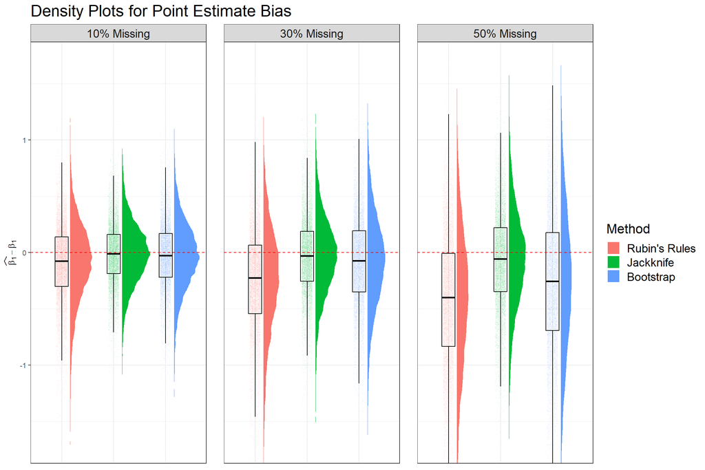

At lower levels of missingness, the point estimation performance of the methods examined is comparable, with nearly unbiased estimates across the board. As the proportion of missingness increases, however, negative biases are noted, particularly for Rubin’s approach. In contrast, it is noted that the jackknife approach continues to provide nearly unbiased estimates, even at high proportions of missingness, where the two other methods have begun to fail. Given the asymptotic nature of bootstrap resampling, it is reasonable to see failures arise as more and more data is lost to missingness. The foregoing idea likely accounts for the slight decrease in performance experienced by the bootstrap approach as the proportion of missingness changes from 10% to 30% and the much more significant deterioration in performance transitioning from 30% to 50%. The later transition likely causes the bootstrapped samples to become less representative of the population, causing biased point estimates. It is interesting to note that, despite its tremendous computational cost, the bootstrap method provides only slightly better point estimates compared to Rubin’s rules at 50% missingness at comparable variability.

## Confidence Intervals

Coverage Probabilities Grouped by Proportion of Missingness (%)

| Proportion of Missingness | Rubin’s Rules | Jackknife | Bootstrap |
| --- | --- | --- | --- |
| 10 | 97.11 | 94.04 | 96.98 |
| 30 | 97.58 | 97.79 | 98.46 |
| 50 | 97.12 | 98.15 | 96.21 |

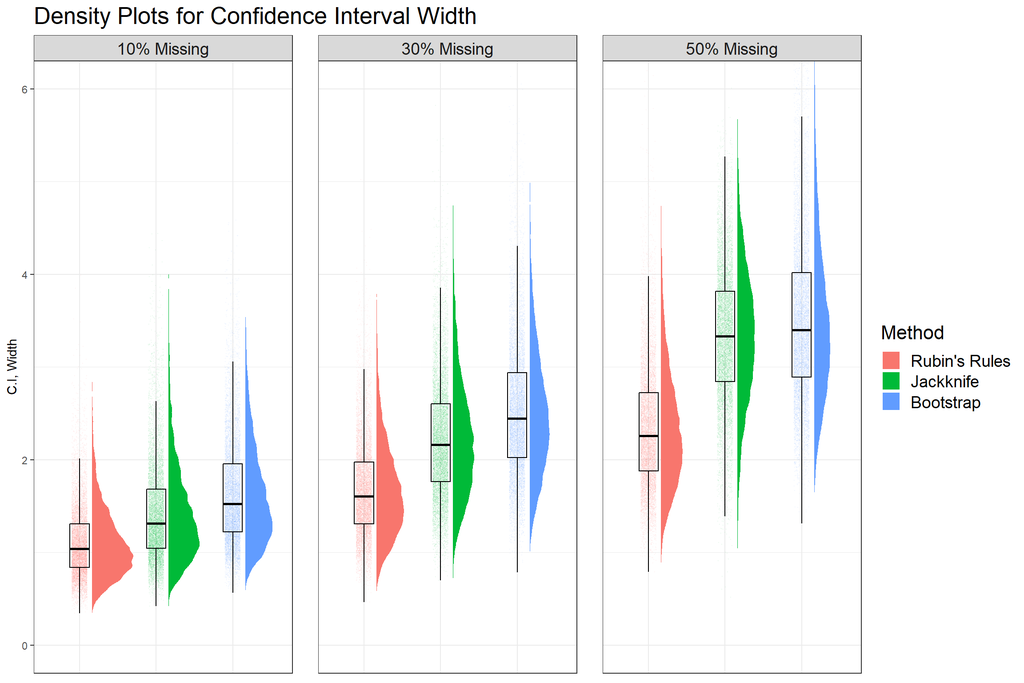

Confidence Interval Width Grouped by Proportion of Missingness

[output not shown]

## Computational Expense

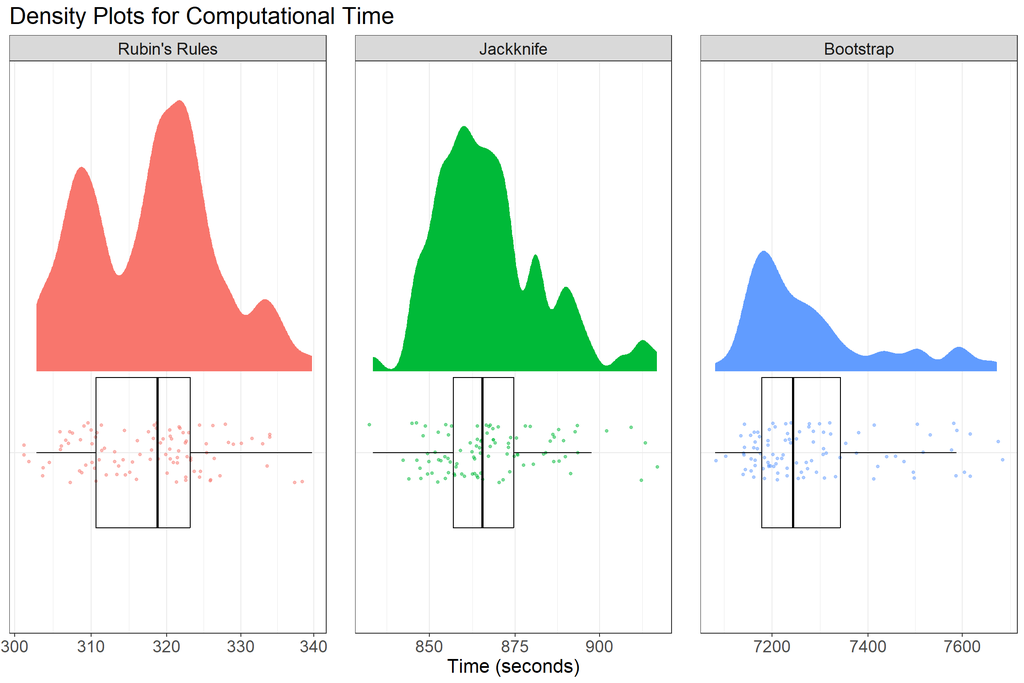

Summary Statistics for Computational Time (seconds)

| Method | Mean | SD | Range |
| --- | --- | --- | --- |
| Rubin’s Rules | 318.08 | 8.67 | 36.90 |
| Jackknife | 867.63 | 16.11 | 83.53 |
| Bootstrap | 7287.55 | 144.33 | 591.61 |

# Discussion

Given the theoretical issues outlined previously with Rubin’s rules under uncongeniality, there is a great need for alternative estimators that can be used in conjunction with multiple imputation. Although bootstrap sampling, as well as its various computationally efficient variants, greatly address such need, the need for approaches that can perform well in smaller sample sizes is still one that needs to be addressed. Given the superior point estimation performance of the jackknife approach proposed, where even at 50% missingness nearly unbiased point estimates were obtained, as well as its fair computational expense and confidence interval characteristics, we think it has the potential to address the foregoing gap in the literature identified.

# Appendix

## Notation

- $N$ is the total number of units in the finite population being targeted.
- $X$ is an $N \times q$ matrix of fully observed covariates.
- $Y$ is an $N \times p$ matrix of partially observed outcome variables.
- $R$ is an $N \times p$ matrix of response indicators (i.e., $R_{ij} = 1$ if the response on $Y_{ij}$ is obtained and $R_{ij} = 0$ otherwise.)
- $Q$ is an unknown quantity of interest to the analyst.
- $Z_c = \{X, Y_{inc}\}$ is the complete data.
- $Z_o = \{X, Y_{obs}, R_{inc}\}$ is the incomplete (i.e., observed) data.
- The analyst’s complete-data procedure is summarized by $\mathscr{P}_{com} = [\hat{Q}(X, Y_{inc}), U(X, Y_{inc})]$, where $\hat{Q}(X, Y_{inc})$ is an estimator of $Q$ with associated variance $U(X, Y_{inc}.)$
- $R$ is not a part of $\mathscr{P}_{com}$, as the missing at random assumption implies that the response behavior itself carries no information about $Q$.

## Formal Definition of Congeniality

### Condition I

Let $E_f$ and $V_f$ denote posterior mean and variance with respect to $f$, respectively. A Bayesian model $f$ is said to be congenial to the analysis procedure $\mathscr{P} \equiv \{\mathscr{P}_{obs}; \mathscr{P}_{com}\}$ for given $Z_o$ if the following hold:

- The posterior mean and variance of $\theta$ under $f$ given the incomplete data are asymptotically the same as the estimate and variance from the analyst’s incomplete-data procedure $\mathscr{P}_{obs}$, that is,
  $$\begin{equation}
  [\hat{\theta}(Z_o), U(Z_o)] \simeq [E_f[\theta | Z_o], V_f[\theta |
  Z_o]]
  \end{equation}$$
- The posterior mean and variance of $\theta$ under $f$ given the complete data are asymptotically the same as the estimate and variance from the analyst’s complete-data procedure $\mathscr{P}_{com}$, that is,
  $$\begin{equation}
  [\hat{\theta}(Z_c), U(Z_c)] \simeq [E_f[\theta | Z_c], V_f[\theta |
  Z_c]]
  \end{equation}$$

  for any possible $Y_{inc} = (Y_{obs}, Y_{miss})$ with $Y_{obs}$ conditioned upon.

If the foregoing conditions are met, $f$ is said to be second-moment congenial to $\mathscr{P}$.

### Condition II

The analysis procedure $\mathscr{P}$ is said to be congenial to the imputation model $g(Y_{miss}|Z_o, A)$ where $A$ represents possible additional data the imputer has access to, if one can find an $f$ such that (**i**) $f$ is congenial to $\mathscr{P}$ and (**ii**) the posterior predictive density for $Y_{miss}$ derived under $f$ is identical to the imputation model $f(Y_{miss}|Z_o) = g(Y_{miss}|Z_o, A) \ \forall \ Y_{miss}$.

## Mechanisms of Missingness

The underlying mechanism of missingness can be classified as missing completely at random (MCAR), missing at random (MAR), or missing not at random (MNAR). In instances where the probability of missingness is independent of all observed variables, data are said to be MCAR. Conversely, in instances where the probability of missingness is directly related to the measurement itself, data are said to be MNAR. Finally, data are said to be MAR when the probability of missingness is independent of the measure itself but dependent on some other observed variable.

Of the three categories, the most desirable is MCAR, as case-wise deletion does not introduce any biases to the analysis procedure. However, MCAR is considered a highly optimistic assumption that rarely holds in practice. As such, a much more reasonable assumption is the MAR assumption, which assumes that the observed values can completely model the probability of missingness. At this point, it is worth noting that missingness mechanisms describe a continuum rather than strict categories. It could be argued that even the MAR assumption is one that rarely holds in practice and that all missing data are MNAR; however, there are instances where the observed values contain sufficient information to model the probability of missingness. In such cases, a proper imputation model that utilizes auxiliary variables, domain expertise, and observed values can make the mechanism of missingness more MAR than MNAR.

## Code

Please see our publicly available GitHub [repository](https://github.com/ieb2/jackknife_var_est.git) for the R code associated with the simulation, data manipulation, and visualization.

Anderson, James C., and David W. Gerbing. 1984. “The Effect of Sampling Error on Convergence, Improper Solutions, and Goodness-of-Fit Indices for Maximum Likelihood Confirmatory Factor Analysis.” *Psychometrika* 49 (2): 155–73. https://doi.org/10.1007/BF02294170.

Bartlett, Jonathan W. 2021. “Reference-Based Multiple Imputation—What Is the Right Variance and How to Estimate It.” *Statistics in Biopharmaceutical Research*, November, 1–9. https://doi.org/10.1080/19466315.2021.1983455.

Bartlett, Jonathan W, and Rachael A Hughes. 2020. “Bootstrap Inference for Multiple Imputation Under Uncongeniality and Misspecification.” *Statistical Methods in Medical Research* 29 (12): 3533–46. https://doi.org/10.1177/0962280220932189.

Bentler, P. M., and Chih-Ping Chou. 1987. “Practical Issues in Structural Modeling.” *Sociological Methods & Research* 16 (1): 78–117. https://doi.org/10.1177/0049124187016001004.

Buuren, Stef van. 2012. *Flexible Imputation of Missing Data*. Chapman & Hall/CRC Interdisciplinary Statistics Series. Boca Raton, FL: CRC Press.

Chen, Jiahua, and Jun Shao. 2001. “Jackknife Variance Estimation for Nearest-Neighbor Imputation.” *Journal of the American Statistical Association* 96 (453): 260–69. https://doi.org/10.1198/016214501750332839.

Faber, Jorge, and Lilian Martins Fonseca. 2014. “How Sample Size Influences Research Outcomes.” *Dental Press Journal of Orthodontics* 19 (4): 27–29. https://doi.org/10.1590/2176-9451.19.4.027-029.ebo.

Fay, Robert E. 1992. “When Are Inferences from Multiple Imputation Valid?.”

Jackson, Dennis L. 2001. “Sample Size and Number of Parameter Estimates in Maximum Likelihood Confirmatory Factor Analysis: A Monte Carlo Investigation.” *Structural Equation Modeling: A Multidisciplinary Journal* 8 (2): 205–23. https://doi.org/10.1207/S15328007SEM0802_3.

LaFontaine, Denise. 2021. “The History of Bootstrapping: Tracing the Development of Resampling with Replacement.” *The Mathematics Enthusiast* 18 (1–2): 78–99. https://doi.org/10.54870/1551-3440.1515.

Mammen, Enno. 1992. *When Does Bootstrap Work?* Vol. 77. Lecture Notes in Statistics. New York, NY: Springer New York. https://doi.org/10.1007/978-1-4612-2950-6.

Meng, Xiao-Li. 1994. “Multiple-Imputation Inferences with Uncongenial Sources of Input.” *Statistical Science* 9 (4): 538–58. https://doi.org/10.1214/ss/1177010269.

Rao, J. N. K., and J. Shao. 1992. “Jackknife Variance Estimation with Survey Data Under Hot Deck Imputation.” *Biometrika* 79 (4): 811–22. https://doi.org/10.2307/2337236.

Rubin, Donald B. 1978. “Multiple Imputations in Sample Surveys-a Phenomenological Bayesian Approach to Nonresponse.” In *Proceedings of the Survey Research Methods Section of the American Statistical Association*, 1:20–34. American Statistical Association Alexandria, VA, USA.

Shao, Jun, and C. F. J. Wu. 1989. “A General Theory for Jackknife Variance Estimation.” *The Annals of Statistics* 17 (3): 1176–97. https://doi.org/10.1214/aos/1176347263.

Wang, N. 1998. “Large-Sample Theory for Parametric Multiple Imputation Procedures.” *Biometrika* 85 (4): 935–48. https://doi.org/10.1093/biomet/85.4.935.

Weisstein, Eric W. n.d. “Smooth Function.” Text. https://mathworld.wolfram.com/.

Wicklin, Rick. 2017. “Jackknife Estimates in SAS.” *SAS Blog*. https://blogs.sas.com/content/iml/2017/06/21/jackknife-estimate-standard-error-sas.html.

Xie, Xianchao, and Xiao-Li Meng. 2016. “Dissecting Multiple Imputation from a Multi-Phase Inference Perspective: What Happens When God’s, Imputer’s and Analyst’s Models Are Uncongenial?” *Statistica Sinica*. https://doi.org/10.5705/ss.2014.067.

[^1]: Please see the appendix for a detailed overview of congeniality.
[^2]: i.i.d stands for independent and identically distributed, which is used to summarize two characteristics about the data; (1) that the samples are all taken from the same probability distribution, and (2) that the samples are obtained independently.